# SPSS to R Conversion Course

#### Step 3 - Treating missing data

We may have also noticed that our dataset contains missing values. Thankfully R has loads of useful packages to make working with missing data much easier. Getting to know what’s missing in your life/data is very important to ensure that our analysis is accurate. For today, we will give a quick and easy overview to working with the missing data, using the `naniar` package.

```r
pct_miss(df_1) # provides percentage of total missing data
```

```
## [1] 5.908289
```

```r
miss_case_summary(df_1) # breaks down missing data percentage by each case
```

```
## # A tibble: 42 × 3
##     case n_miss pct_miss
##    <int>  <int>    <dbl>
##  1    41     24    88.9
##  2    42     19    70.4
##  3     2      2     7.41
##  4     4      2     7.41
##  5     6      2     7.41
##  6    17      2     7.41
##  7    20      2     7.41
##  8    21      2     7.41
##  9    25      2     7.41
## 10     8      1     3.70
## # ℹ 32 more rows
```

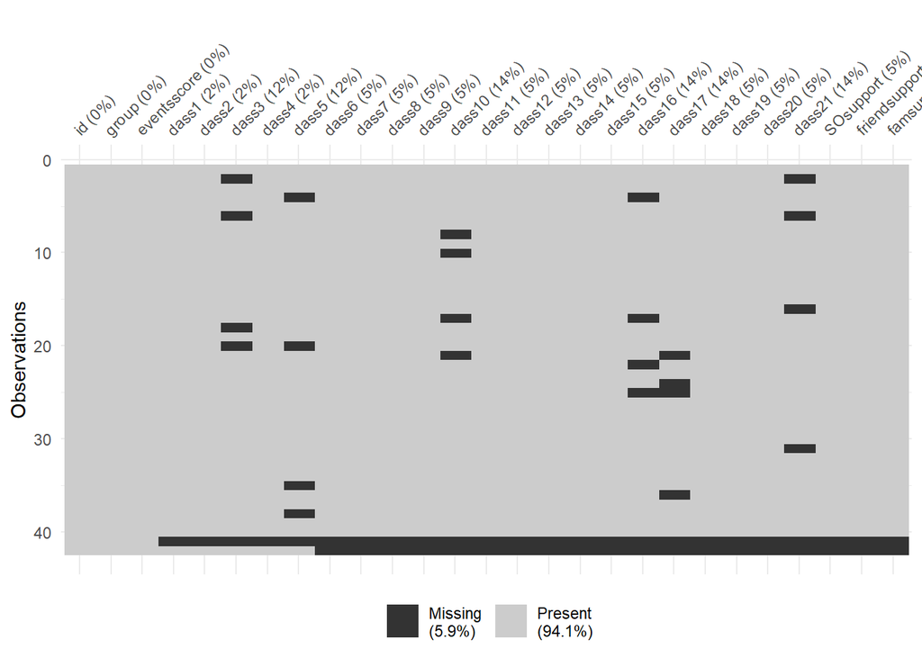

```r
vis_miss(df_1) # Visually inspect data
```

We can see that case 41 and 42 have a lot of missing entries from the above summary. These participants need to be removed.

```r
df_2 <- df_1[-c(41,42), ] # using base R to manually remove participants, using the minus symbol.

pct_miss(df_2)
```

```
## [1] 2.222222
```

```r
miss_case_summary(df_2)
```

```
## # A tibble: 40 × 3
##     case n_miss pct_miss
##    <int>  <int>    <dbl>
##  1     2      2     7.41
##  2     4      2     7.41
##  3     6      2     7.41
##  4    17      2     7.41
##  5    20      2     7.41
##  6    21      2     7.41
##  7    25      2     7.41
##  8     8      1     3.70
##  9    10      1     3.70
## 10    16      1     3.70
## # ℹ 30 more rows
```

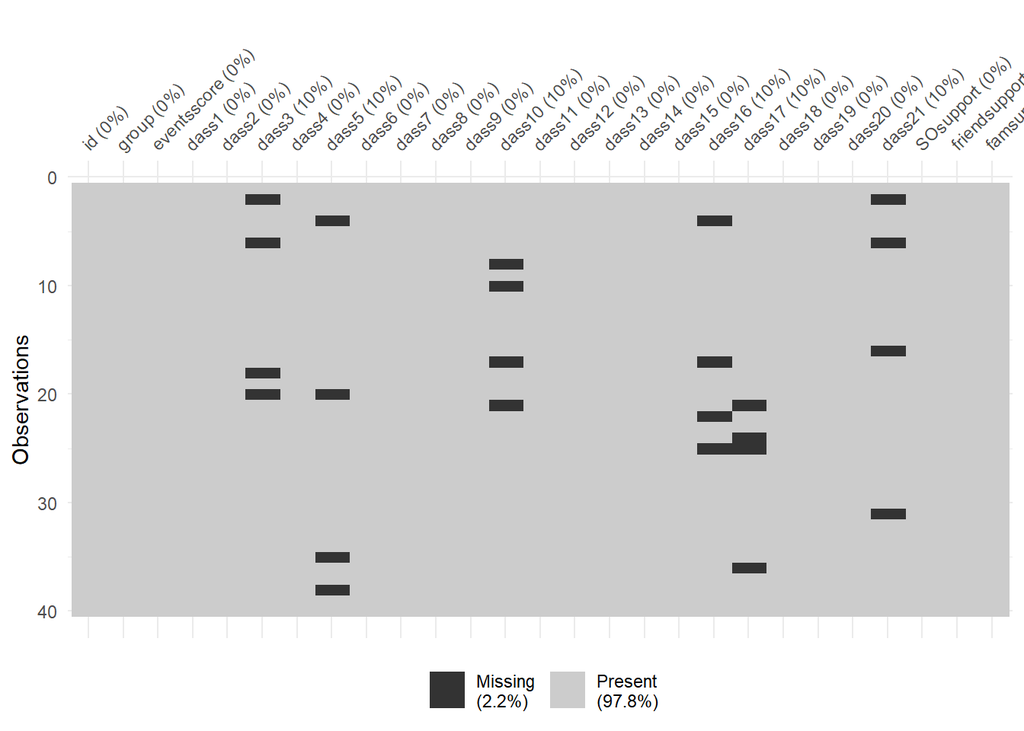

```r
vis_miss(df_2)
```

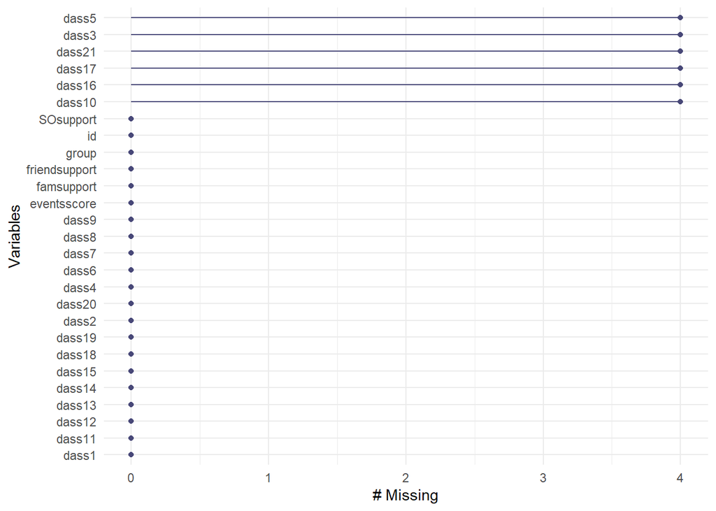

```r
gg_miss_var(df_2) # using gg_miss_var to visualise missing data by variable.
```

For the others, we will impute based on row-mean values within each subscale. Whilst not as sophisticated as methods such as Multiple Chained Imputation Equations, it is much simpler to conceptually understand. It is also a robust alternative that has comparable effectiveness for dealing with missing data in psychometric subscales under conditions of low % Missing Completely At Random data [(Parent, 2012)](https://journals.sagepub.com/doi/full/10.1177/0011000012445176). The missing data for today was simulated to match these conditions.

Conveniently, we will notice that all of our missing variables all belong to the depression subscale… How magically convenient! This may/will not be the case for real data, but it is helpful for today, as it stops us being overwhelmed with code.

```r
Depression_data <- df_2  %>%
  dplyr::select(dass3, dass5, dass10, dass16, dass17, dass21)

#Step 2 - applying rowwise imputation to the selected data



Depression_fix <- apply_imputation(Depression_data,
                                   FUN = mean,
                                   type = "rowwise")


#Step 3 - updating dataset with imputed data - do this by subscale to help brain manage.
 df_3 <- df_2 %>% mutate(
  dass3 = Depression_fix$dass3,
  dass5 = Depression_fix$dass5,
  dass10 = Depression_fix$dass10,
  dass16 = Depression_fix$dass16,
  dass17 = Depression_fix$dass17,
  dass21 = Depression_fix$dass21,
)
```

#### Step 4 - Creating composite variables

```r
## Task - compute the DASS subscales. Stress has already been calculated in the code below as an example. Don't forget to use a comma between each command in the `mutate()` function.

# Stress: items  dass1, dass6, dass8, dass11, dass12, dass14, dass18
#
# Anxiety: items  dass2, dass4, dass7, dass9, dass15, dass19, dass20
#
# Depression: items  dass3, dass5, dass10, dass13, dass16, dass17,  dass21


#Uncomment the tip below and complete the missing bits

#df_4 <- df_3 %>%
  #mutate( # Using mutate to create composite variables
    #stress = dass1 + dass6 + dass8 + dass11 + dass12 + dass14 + dass18,
    #anxiety = ... ,
   # depression = ...
 # )
```

Below is the solution of the exercise above

```r
## Results

df_4 <- df_3 %>%
  mutate( # Using mutate to create composite variables
    stress = dass1 + dass6 + dass8 + dass11 + dass12 + dass14 + dass18,
    anxiety = dass2 + dass4 + dass7 + dass9 + dass15 + dass19 + dass20 ,
    depression = dass3 + dass5 + dass10 + dass13 + dass16 + dass17 + dass21
 )
```

#### Step 5 - Filtering data

Here we will be performing the bane of most researchers - filtering. This includes removing suspect bots, removing duplicates, removing participants who did not finish survey, and removing outliers.

Today, we will focus on removing outliers on the basis of Z-scores. This is when data is standardised, so that the mean value is 0, and each participant score is converted to their relative standard deviation position. Any participant with entries with less than -3, or greater than +3 can be considered to be a large/influential outlier [(Osbourne & Overbray, 2004)](https://scholarworks.umass.edu/cgi/viewcontent.cgi?article=1139&context=pare). As such, there is justification to remove them from the data. Prior to this, we need to inspect our data.

```r
summary(df_4) # Using summary to inspect our data
```

```
##        id               group     eventsscore      dass1         dass2
##  Min.   : 1.00   control   :16   Min.   :0.0   Min.   :0.0   Min.   :0.00
##  1st Qu.:10.75   experiment:24   1st Qu.:2.0   1st Qu.:1.0   1st Qu.:0.00
##  Median :20.50                   Median :3.5   Median :1.0   Median :1.00
##  Mean   :20.50                   Mean   :3.8   Mean   :1.3   Mean   :0.85
##  3rd Qu.:30.25                   3rd Qu.:5.0   3rd Qu.:2.0   3rd Qu.:1.00
##  Max.   :40.00                   Max.   :9.0   Max.   :3.0   Max.   :3.00
##      dass3           dass4          dass5           dass6          dass7
##  Min.   :0.000   Min.   :0.00   Min.   :0.000   Min.   :0.00   Min.   :0.000
##  1st Qu.:0.000   1st Qu.:0.00   1st Qu.:0.000   1st Qu.:1.00   1st Qu.:0.000
##  Median :1.000   Median :1.00   Median :1.000   Median :1.00   Median :1.000
##  Mean   :1.069   Mean   :0.85   Mean   :1.222   Mean   :1.35   Mean   :0.675
##  3rd Qu.:2.000   3rd Qu.:1.00   3rd Qu.:2.000   3rd Qu.:2.00   3rd Qu.:1.000
##  Max.   :3.000   Max.   :3.00   Max.   :3.000   Max.   :3.00   Max.   :2.000
##      dass8           dass9         dass10         dass11        dass12
##  Min.   :0.000   Min.   :0.0   Min.   :0.00   Min.   :0.0   Min.   :0.000
##  1st Qu.:0.000   1st Qu.:0.0   1st Qu.:0.00   1st Qu.:0.0   1st Qu.:0.000
##  Median :1.000   Median :1.0   Median :1.00   Median :1.0   Median :1.000
##  Mean   :1.175   Mean   :0.9   Mean   :1.01   Mean   :1.3   Mean   :1.275
##  3rd Qu.:2.000   3rd Qu.:1.0   3rd Qu.:2.00   3rd Qu.:2.0   3rd Qu.:2.000
##  Max.   :3.000   Max.   :3.0   Max.   :3.00   Max.   :3.0   Max.   :3.000
##      dass13          dass14        dass15          dass16          dass17
##  Min.   :0.000   Min.   :0.0   Min.   :0.000   Min.   :0.000   Min.   :0.000
##  1st Qu.:0.000   1st Qu.:1.0   1st Qu.:0.000   1st Qu.:0.000   1st Qu.:0.000
##  Median :1.000   Median :1.0   Median :1.000   Median :1.000   Median :1.000
##  Mean   :1.075   Mean   :1.4   Mean   :1.075   Mean   :1.056   Mean   :0.865
##  3rd Qu.:2.000   3rd Qu.:2.0   3rd Qu.:2.000   3rd Qu.:2.000   3rd Qu.:1.250
##  Max.   :3.000   Max.   :3.0   Max.   :3.000   Max.   :3.000   Max.   :3.000
##      dass18          dass19        dass20          dass21         SOsupport
##  Min.   :0.000   Min.   :0.0   Min.   :0.000   Min.   :0.0000   Min.   : 4.00
##  1st Qu.:0.000   1st Qu.:0.0   1st Qu.:0.000   1st Qu.:0.0000   1st Qu.:19.75
##  Median :1.000   Median :1.0   Median :1.000   Median :1.0000   Median :24.50
##  Mean   :1.225   Mean   :0.9   Mean   :0.875   Mean   :0.9625   Mean   :22.70
##  3rd Qu.:2.000   3rd Qu.:1.0   3rd Qu.:1.250   3rd Qu.:1.8125   3rd Qu.:28.00
##  Max.   :3.000   Max.   :3.0   Max.   :3.000   Max.   :3.0000   Max.   :28.00
##  friendsupport     famsupport        stress          anxiety
##  Min.   : 7.00   Min.   : 4.00   Min.   : 1.000   Min.   : 1.000
##  1st Qu.:19.00   1st Qu.:16.75   1st Qu.: 3.000   1st Qu.: 2.000
##  Median :20.50   Median :20.00   Median : 7.500   Median : 4.500
##  Mean   :20.95   Mean   :19.10   Mean   : 9.025   Mean   : 6.125
##  3rd Qu.:24.75   3rd Qu.:23.25   3rd Qu.:13.250   3rd Qu.: 9.250
##  Max.   :28.00   Max.   :28.00   Max.   :21.000   Max.   :19.000
##    depression
##  Min.   : 0.000
##  1st Qu.: 1.875
##  Median : 5.650
##  Mean   : 7.260
##  3rd Qu.:12.125
##  Max.   :21.000
```

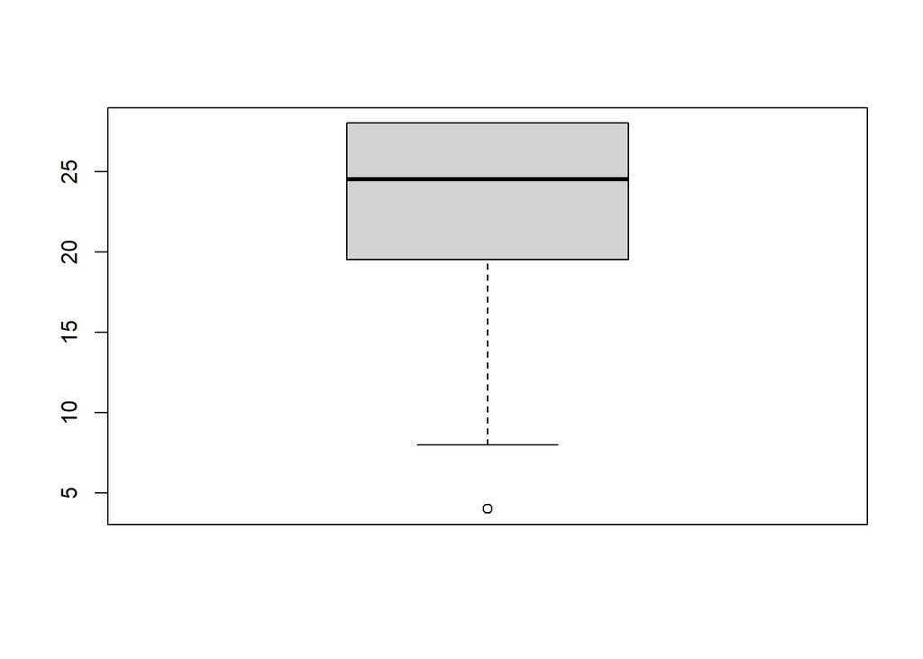

```r
# Using plots to visually inspect our data
boxplot(df_4$SOsupport) # Any outliers in boxplot?
```

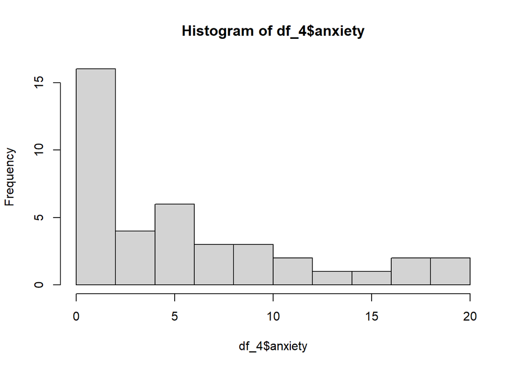

```r
hist(df_4$anxiety) # How is the data distributed? (Does it make sense regarding the literature?)
```

```r
## Task - visually inspect the outliers and distribution of the stress and depression sub scales below:
```

Now that we have visually inspected our data, we can apply the code to remove our outliers.

```r
# Creating Z score of study measures - useful for subjectively removing outliers.
df_5 <- df_4 %>%
  mutate(Z_score_life_events = scale(eventsscore),
         Z_score_anxiety = scale(anxiety),
         Z_score_stress = scale(stress),
         Z_score_depression = scale(depression),
         Z_score_SOsupport = scale(SOsupport),
         Z_score_friendsupport = scale(friendsupport),
         Z_score_famsupport = scale(famsupport)
         )

summary(df_5) # Which variable has a Z-score that breaks our +3/-3 boundary?
```

```
##        id               group     eventsscore      dass1         dass2
##  Min.   : 1.00   control   :16   Min.   :0.0   Min.   :0.0   Min.   :0.00
##  1st Qu.:10.75   experiment:24   1st Qu.:2.0   1st Qu.:1.0   1st Qu.:0.00
##  Median :20.50                   Median :3.5   Median :1.0   Median :1.00
##  Mean   :20.50                   Mean   :3.8   Mean   :1.3   Mean   :0.85
##  3rd Qu.:30.25                   3rd Qu.:5.0   3rd Qu.:2.0   3rd Qu.:1.00
##  Max.   :40.00                   Max.   :9.0   Max.   :3.0   Max.   :3.00
##      dass3           dass4          dass5           dass6          dass7
##  Min.   :0.000   Min.   :0.00   Min.   :0.000   Min.   :0.00   Min.   :0.000
##  1st Qu.:0.000   1st Qu.:0.00   1st Qu.:0.000   1st Qu.:1.00   1st Qu.:0.000
##  Median :1.000   Median :1.00   Median :1.000   Median :1.00   Median :1.000
##  Mean   :1.069   Mean   :0.85   Mean   :1.222   Mean   :1.35   Mean   :0.675
##  3rd Qu.:2.000   3rd Qu.:1.00   3rd Qu.:2.000   3rd Qu.:2.00   3rd Qu.:1.000
##  Max.   :3.000   Max.   :3.00   Max.   :3.000   Max.   :3.00   Max.   :2.000
##      dass8           dass9         dass10         dass11        dass12
##  Min.   :0.000   Min.   :0.0   Min.   :0.00   Min.   :0.0   Min.   :0.000
##  1st Qu.:0.000   1st Qu.:0.0   1st Qu.:0.00   1st Qu.:0.0   1st Qu.:0.000
##  Median :1.000   Median :1.0   Median :1.00   Median :1.0   Median :1.000
##  Mean   :1.175   Mean   :0.9   Mean   :1.01   Mean   :1.3   Mean   :1.275
##  3rd Qu.:2.000   3rd Qu.:1.0   3rd Qu.:2.00   3rd Qu.:2.0   3rd Qu.:2.000
##  Max.   :3.000   Max.   :3.0   Max.   :3.00   Max.   :3.0   Max.   :3.000
##      dass13          dass14        dass15          dass16          dass17
##  Min.   :0.000   Min.   :0.0   Min.   :0.000   Min.   :0.000   Min.   :0.000
##  1st Qu.:0.000   1st Qu.:1.0   1st Qu.:0.000   1st Qu.:0.000   1st Qu.:0.000
##  Median :1.000   Median :1.0   Median :1.000   Median :1.000   Median :1.000
##  Mean   :1.075   Mean   :1.4   Mean   :1.075   Mean   :1.056   Mean   :0.865
##  3rd Qu.:2.000   3rd Qu.:2.0   3rd Qu.:2.000   3rd Qu.:2.000   3rd Qu.:1.250
##  Max.   :3.000   Max.   :3.0   Max.   :3.000   Max.   :3.000   Max.   :3.000
##      dass18          dass19        dass20          dass21         SOsupport
##  Min.   :0.000   Min.   :0.0   Min.   :0.000   Min.   :0.0000   Min.   : 4.00
##  1st Qu.:0.000   1st Qu.:0.0   1st Qu.:0.000   1st Qu.:0.0000   1st Qu.:19.75
##  Median :1.000   Median :1.0   Median :1.000   Median :1.0000   Median :24.50
##  Mean   :1.225   Mean   :0.9   Mean   :0.875   Mean   :0.9625   Mean   :22.70
##  3rd Qu.:2.000   3rd Qu.:1.0   3rd Qu.:1.250   3rd Qu.:1.8125   3rd Qu.:28.00
##  Max.   :3.000   Max.   :3.0   Max.   :3.000   Max.   :3.0000   Max.   :28.00
##  friendsupport     famsupport        stress          anxiety
##  Min.   : 7.00   Min.   : 4.00   Min.   : 1.000   Min.   : 1.000
##  1st Qu.:19.00   1st Qu.:16.75   1st Qu.: 3.000   1st Qu.: 2.000
##  Median :20.50   Median :20.00   Median : 7.500   Median : 4.500
##  Mean   :20.95   Mean   :19.10   Mean   : 9.025   Mean   : 6.125
```

[output cut: 8 more lines]

```
##  Max.   :21.000   Max.   : 2.3054983     Max.   : 2.3111044
##   Z_score_stress.V1   Z_score_depression.V1 Z_score_SOsupport.V1
##  Min.   :-1.2580338   Min.   :-1.1032597    Min.   :-3.182635
##  1st Qu.:-0.9445051   1st Qu.:-0.8183269    1st Qu.:-0.502073
##  Median :-0.2390656   Median :-0.2446623    Median : 0.306350
##  Mean   : 0.0000000   Mean   : 0.0000000    Mean   : 0.000000
##  3rd Qu.: 0.6623293   3rd Qu.: 0.7393056    3rd Qu.: 0.902030
##  Max.   : 1.8772529   Max.   : 2.0879874    Max.   : 0.902030
##  Z_score_friendsupport.V1 Z_score_famsupport.V1
##  Min.   :-2.3888948       Min.   :-2.3771801
##  1st Qu.:-0.3339315       1st Qu.:-0.3699585
##  Median :-0.0770611       Median : 0.1416862
##  Mean   : 0.0000000       Mean   : 0.0000000
##  3rd Qu.: 0.6507384       3rd Qu.: 0.6533309
##  Max.   : 1.2072909       Max.   : 1.4011194
```

```r
### Note: Z-scores between -3 and +3 are recommended as cuttoff for non-exponential data. May not always be appropriate, so know your data first.

#We can use the results of the above summary to identify the variable that needs filtering.


df_6 <- df_5 %>% filter(
         Z_score_SOsupport <= 3 ,
         Z_score_SOsupport >= -3
  )
summary(df_6)
```

```
##        id               group     eventsscore        dass1
##  Min.   : 1.00   control   :16   Min.   :0.000   Min.   :0.000
##  1st Qu.:10.50   experiment:23   1st Qu.:2.000   1st Qu.:1.000
##  Median :20.00                   Median :4.000   Median :1.000
##  Mean   :20.46                   Mean   :3.846   Mean   :1.308
##  3rd Qu.:30.50                   3rd Qu.:5.000   3rd Qu.:2.000
##  Max.   :40.00                   Max.   :9.000   Max.   :3.000
##      dass2            dass3           dass4            dass5
##  Min.   :0.0000   Min.   :0.000   Min.   :0.0000   Min.   :0.000
##  1st Qu.:0.0000   1st Qu.:0.000   1st Qu.:0.0000   1st Qu.:0.000
##  Median :1.0000   Median :1.000   Median :1.0000   Median :1.000
##  Mean   :0.8462   Mean   :1.071   Mean   :0.8462   Mean   :1.228
##  3rd Qu.:1.0000   3rd Qu.:2.000   3rd Qu.:1.0000   3rd Qu.:2.000
##  Max.   :3.0000   Max.   :3.000   Max.   :3.0000   Max.   :3.000
##      dass6           dass7            dass8           dass9
##  Min.   :0.000   Min.   :0.0000   Min.   :0.000   Min.   :0.0000
##  1st Qu.:1.000   1st Qu.:0.0000   1st Qu.:0.000   1st Qu.:0.0000
##  Median :1.000   Median :1.0000   Median :1.000   Median :1.0000
##  Mean   :1.359   Mean   :0.6667   Mean   :1.179   Mean   :0.8974
##  3rd Qu.:2.000   3rd Qu.:1.0000   3rd Qu.:2.000   3rd Qu.:1.0000
##  Max.   :3.000   Max.   :2.0000   Max.   :3.000   Max.   :3.0000
##      dass10         dass11          dass12          dass13          dass14
##  Min.   :0.00   Min.   :0.000   Min.   :0.000   Min.   :0.000   Min.   :0.00
##  1st Qu.:0.00   1st Qu.:0.000   1st Qu.:0.000   1st Qu.:0.000   1st Qu.:1.00
##  Median :1.00   Median :1.000   Median :1.000   Median :1.000   Median :1.00
##  Mean   :1.01   Mean   :1.308   Mean   :1.282   Mean   :1.077   Mean   :1.41
##  3rd Qu.:2.00   3rd Qu.:2.000   3rd Qu.:2.000   3rd Qu.:2.000   3rd Qu.:2.00
##  Max.   :3.00   Max.   :3.000   Max.   :3.000   Max.   :3.000   Max.   :3.00
##      dass15          dass16          dass17           dass18
##  Min.   :0.000   Min.   :0.000   Min.   :0.0000   Min.   :0.000
##  1st Qu.:0.000   1st Qu.:0.000   1st Qu.:0.0000   1st Qu.:0.500
##  Median :1.000   Median :1.000   Median :1.0000   Median :1.000
##  Mean   :1.077   Mean   :1.058   Mean   :0.8615   Mean   :1.256
##  3rd Qu.:2.000   3rd Qu.:2.000   3rd Qu.:1.5000   3rd Qu.:2.000
##  Max.   :3.000   Max.   :3.000   Max.   :3.0000   Max.   :3.000
##      dass19           dass20           dass21         SOsupport
##  Min.   :0.0000   Min.   :0.0000   Min.   :0.0000   Min.   : 8.00
##  1st Qu.:0.0000   1st Qu.:0.0000   1st Qu.:0.0000   1st Qu.:20.00
##  Median :1.0000   Median :1.0000   Median :1.0000   Median :25.00
##  Mean   :0.8974   Mean   :0.8974   Mean   :0.9615   Mean   :23.18
```

[output cut: 15 more lines]

```
##  Max.   :21.000   Max.   : 2.3054983     Max.   : 2.3111044
##   Z_score_stress.V1   Z_score_depression.V1 Z_score_SOsupport.V1
##  Min.   :-1.2580338   Min.   :-1.1032597    Min.   :-2.5018576
##  1st Qu.:-0.9445051   1st Qu.:-0.8373224    1st Qu.:-0.4595249
##  Median :-0.1606834   Median :-0.2674569    Median : 0.3914471
##  Mean   : 0.0121593   Mean   : 0.0010131    Mean   : 0.0816060
##  3rd Qu.: 0.7015204   3rd Qu.: 0.7583011    3rd Qu.: 0.9020303
##  Max.   : 1.8772529   Max.   : 2.0879874    Max.   : 0.9020303
##  Z_score_friendsupport.V1 Z_score_famsupport.V1
##  Min.   :-2.3888948       Min.   :-2.3771801
##  1st Qu.:-0.3339315       1st Qu.:-0.4093158
##  Median : 0.0085623       Median : 0.1416862
##  Mean   : 0.0612537       Mean   :-0.0359261
##  3rd Qu.: 0.7791736       3rd Qu.: 0.6139737
##  Max.   : 1.2072909       Max.   : 1.4011194
```

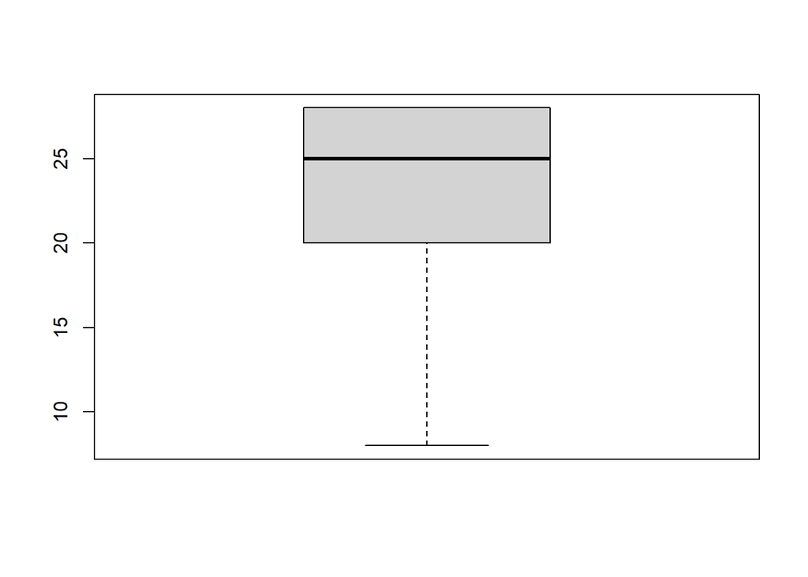

```r
boxplot(df_6$SOsupport) # New boxplot
```

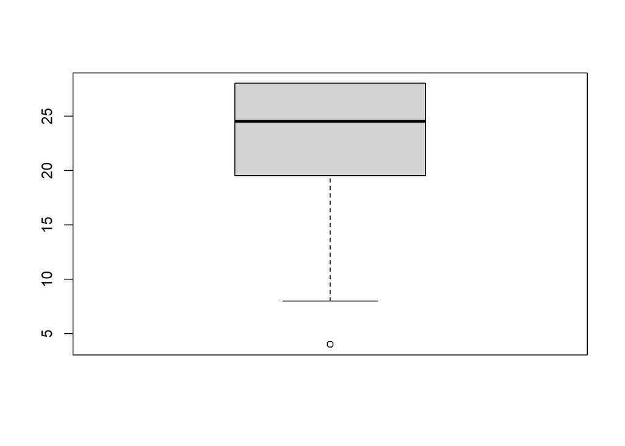

```r
boxplot(df_4$SOsupport) # Boxplot with outliers
```

#### Step 5 - Saving a copy of our analysis ready data.

Now that our data is ready, we can save a copy. This can help us save time on future projects, by saving us the hassle of needing to re-run our tidying script every time. It also allows for communication of our data with others who might not want to go through the hassle/pain of data tidying. Because our source file is already set, our newly saved data will pop straight into our folder.

For today, we will work with CSV as the file format. It’s the recommended format, as it can be opened with multiple pieces of software. Data safety, it is also preferred as the file format is safe from system updates/software disengagements. This is because csv files keep data organised through the simple yet effective **comma** **separated** **values** (aka: **C.S.V**). This also allows them to store much larger datasets in comparison to SAV and xlsx file formats, as there is less complications to manage.

This makes it a commonly used file format in data science activities… So if you ever want to make life difficult for anyone who might steal personal data, make sure to include plenty of comma’s in your responses. It will beautifully vandalise their dataset.

```r
#Make sure to check your folder to view your data. Open it up in excel or SPSS if you like!

write.csv(df_6, "~tidy_data.csv")
```

After the above step is complete, we can now re-run our analysis without having to retrace the steps of cleaning every time. In my own practice, I keep a separate script for tidying and a separate script for analysis. I will then use the tidied data for my analysis. Now it is time for a quick break, and then we will continue in our part-2 analysis document.

#### References

Osborne, J. W., & Overbay, A. (2004). The power of outliers (and why researchers should always check for them). Practical Assessment, Research, and Evaluation, 9(1), 6.

Parent, M. C. (2013). Handling item-level missing data: Simpler is just as good.*The Counseling Psychologist*,*41*(4), 568-600.

## Exporting your work

Finally We are going to quickly learn about how R can be used to render documents. This is done using the `Knit` button. To tidy our end document, we will also use some extra commands in our code chunks. The `echo=FALSE` is used to prevent our code from being rendered. Meanwhile, `message = FALSE` is used to prevent any warning messages from being rendered.

```r
#code to upload our newly saved file into R.
df_tidy <- read_csv("~tidy_data.csv") %>% mutate(group = as.factor(group))
summary(df_tidy)
```

[output not shown]

## Running and reporting analyses

Now that the hard work of preparing our data is complete. We can run our analyses! Today we will perform t-tests to compare the effect of the intervention on depression, anxiety and stress.

From there, we will perform a regression analysis to predict depression scores whilst controlling for exposure to stressful life events, social support, and the intervention.

We will also use this to demonstrate how we can use R to generate our analysis reports. So no more copy and pasting. Just smoooooooth sailing.

Here we will be taking advantage of the `flextable` and `gtsummary` packages to conduct and report our statistics. These package makes it super easy to generate publication ready tables, and it can be rendered into Word documents thorugh R!

For more information on how to use the package, please check out the `flextable` [vignettes](https://ardata-fr.github.io/flextable-book/) and the `gtsummary` [vignettes](https://www.danieldsjoberg.com/gtsummary/articles/tbl_summary.html).

The code might look a little intimidating, but we will walk you through it so that you can also use this for your own analysis.

For each analysis, we will display the raw version and the tidied version. We will also show you how to render your analysis to finish the session.

## Summary Statistics

The code for the summary statistics table has been set to display most of the common descriptive summary statistics. Any columns that are not needed can be deleted manually in the rendered word document (Or by digging into `get_summary_stats()` by looking up the [R documentation](https://www.rdocumentation.org/packages/rstatix/versions/0.7.2/topics/get_summary_stats)).

**NB** If you are running the cell below to generate a report that will contains only the output tables make sure to change `echo=TRUE` in the header of the markdown cell into `echo=FALSE`.

```r
table <- df_tidy %>%
  dplyr::select(stress, anxiety, depression, eventsscore, SOsupport) %>%  # Select relevant columns
  tbl_summary(
    type = all_continuous() ~ "continuous",  # Specify that all selected columns are continuous
    statistic = all_continuous() ~ "{mean} ({sd})",  # Customize the statistics
    label = list(stress ~ "Stress Score",    # Optional: Customize labels for better readability
                 anxiety ~ "Anxiety Score",
                 depression ~ "Depression Score",
                 eventsscore ~ "Event Score",
                 SOsupport ~ "Social Support")
  )


as_flex_table(table)  # Converts table to flextable, which makes it prettier and allows for rendering into Word.
```

| Characteristic | N = 391 |
| --- | --- |
| Stress Score | 9.1 (6.4) |
| Anxiety Score | 6.1 (5.6) |
| Depression Score | 7 (7) |
| Event Score | 3.85 (2.27) |
| Social Support | 23.2 (5.1) |

1Mean (SD)

### Cronbach’s alphas

This is probably the most complicated part of the worksheet, as it requires using a combination of different functions. However, we have tried to compile the code so that you can copy, paste and adjust to your own needs.

```r
# Compiling alphas

## Step 1: compiling subscale variables
stress_alpha <- df_tidy %>% dplyr::select(dass1, dass6, dass8,
                                       dass11, dass12, dass14, dass18)
anxiety_alpha <- df_tidy %>% dplyr::select(dass2, dass4, dass7,
                                        dass9, dass15, dass19, dass20)
depression_alpha <- df_tidy %>% dplyr::select(dass3, dass5, dass10,
                                           dass13, dass16, dass17, dass21)

## Step 2: Running the cronbach.alpha test, and collecting only the score.
## If the commands below are not working, run `instal.packages("ltm")` in the console first.

str_alpha_value <- ltm::cronbach.alpha(stress_alpha)[[1]]
anx_alpha_value <- ltm::cronbach.alpha(anxiety_alpha)[[1]]
dep_alpha_value <- ltm::cronbach.alpha(depression_alpha)[[1]]


## Step 3:Creating Subscale names and cronbach alpha values objects - make sure values align with names

alpha_values <- c(str_alpha_value , anx_alpha_value, dep_alpha_value)

Measure_name <- c("DASS Stress",
              "DASS Anxiety",
              "DASS Depression")

## Step 4: Creating a pretty table
data.frame(Measure_name, alpha_values) %>% # Choosing our objects from step 3
  mutate(alpha_values = round(alpha_values, 2)) %>% # Rounding to 2 decimal places
  dplyr::rename( `Measure` = Measure_name, # Renaming so we can include spaces
    `Cronbach alpha` = alpha_values ) %>%
  flextable() # Using flextable() to make prettier table that renders to word.
```

| Measure | Cronbach alpha |
| --- | --- |
| DASS Stress | 0.96 |
| DASS Anxiety | 0.95 |
| DASS Depression | 0.97 |

## T-test report

### Raw results

```r
t_test(stress ~ group, data = df_tidy)
```

```
## # A tibble: 1 × 8
##   .y.    group1  group2        n1    n2 statistic    df      p
## * <chr>  <chr>   <chr>      <int> <int>     <dbl> <dbl>  <dbl>
## 1 stress control experiment    16    23      2.71  30.6 0.0108
```

### Publication ready(er) results

```r
  df_tidy %>%
  dplyr::select(group, anxiety, stress, depression) %>%
  tbl_summary(by = group,
              missing = "no",
              statistic = list(all_continuous() ~ "{mean} ({sd})")) %>%
  add_p(everything() ~ "t.test") %>%
  modify_header( # header needs to be modified to display test statistc and df
    statistic = "**t-statistic**",
    parameter = "**df**"
  )  %>%
  # add a header to the statistic column, which is hidden by default
  modify_fmt_fun(c(statistic , parameter) ~ style_sigfig)
```

| **Characteristic** | **control**, N = 16<sup>1</sup> | **experiment**, N = 23<sup>1</sup> | **t-statistic** | **df** | **p-value**<sup>2</sup> |
| --- | --- | --- | --- | --- | --- |
| anxiety | 9.1 (6.6) | 4.1 (3.8) | 2.7 | 22 | 0.013 |
| stress | 12.3 (6.2) | 6.9 (5.7) | 2.7 | 31 | 0.011 |
| depression | 11 (6) | 4 (5) | 3.5 | 28 | 0.001 |

<sup>1</sup> Mean (SD)  
<sup>2</sup> Welch Two Sample t-test

## Correlation analysis

### Rough results

````r
cor_data <- df_tidy %>%
  dplyr::select( anxiety, stress, depression, eventsscore , SOsupport)

# Calculate correlation
results <- correlation(cor_data)


# Capture the summary output
summary_output <- capture.output(summary(results, redundant = TRUE))

# Wrap the output in markdown code block to avoid header interpretation
cat("```\n", paste(summary_output, collapse = "\n"), "\n```")
````

```
 # Correlation Matrix (pearson-method)

Parameter   | anxiety |  stress | depression | eventsscore | SOsupport
----------------------------------------------------------------------
anxiety     |         | 0.90*** |    0.76*** |        0.38 |     -0.39
stress      | 0.90*** |         |    0.74*** |        0.37 |    -0.46*
depression  | 0.76*** | 0.74*** |            |       0.42* |    -0.48*
eventsscore |    0.38 |    0.37 |      0.42* |             |     -0.24
SOsupport   |   -0.39 |  -0.46* |     -0.48* |       -0.24 |

p-value adjustment method: Holm (1979)
```

### Publication ready(er) results

Please note that the correlation matrix is left with redundant values. This is to allow you to decide if you want to manually display the lower or upper triangle. Also, a bug in the `correlation` package rearranges the display in a displeasing manner when `redundant = FALSE`. But thankfully, we can edit our output to our needs in the rendered word document.

```r
 df_tidy %>% dplyr::select( anxiety, stress, depression, eventsscore , SOsupport) %>%
    rename(`Anxiety` = anxiety ,
           `Stress` = stress,
           `Depression` = depression,
           `Stressful Life Events` =  eventsscore,
           `Significant Other Support`=  SOsupport) %>%
  correlation::correlation() %>%
  summary(redundant = TRUE) %>%
  display()
```

Correlation Matrix (pearson-method)

| Parameter | Anxiety | Stress | Depression | Stressful Life Events | Significant Other Support |
| --- | --- | --- | --- | --- | --- |
| Anxiety |  | 0.90*** | 0.76*** | 0.38 | -0.39 |
| Stress | 0.90*** |  | 0.74*** | 0.37 | -0.46* |
| Depression | 0.76*** | 0.74*** |  | 0.42* | -0.48* |
| Stressful Life Events | 0.38 | 0.37 | 0.42* |  | -0.24 |
| Significant Other Support | -0.39 | -0.46* | -0.48* | -0.24 |  |

p-value adjustment method: Holm (1979)

## Regression analysis

```r
# Setting the model
model <- lm(depression ~ group + eventsscore + SOsupport, df_tidy)
```

### Raw results

```r
# Ugly (but useful) results
summary(model)
```

```
##
## Call:
## lm(formula = depression ~ group + eventsscore + SOsupport, data = df_tidy)
##
## Residuals:
##    Min     1Q Median     3Q    Max
## -7.482 -3.849 -1.341  2.748 11.982
##
## Coefficients:
##                 Estimate Std. Error t value Pr(>|t|)
## (Intercept)      17.8993     4.8397   3.698  0.00074 ***
## groupexperiment  -4.4211     2.0045  -2.206  0.03407 *
## eventsscore       0.5451     0.4332   1.258  0.21662
## SOsupport        -0.4367     0.1798  -2.429  0.02044 *
## ---
## Signif. codes:  0 '***' 0.001 '**' 0.01 '*' 0.05 '.' 0.1 ' ' 1
##
## Residual standard error: 5.353 on 35 degrees of freedom
## Multiple R-squared:  0.4062, Adjusted R-squared:  0.3553
## F-statistic: 7.981 on 3 and 35 DF,  p-value: 0.0003486
```

### Publication ready(er) results

I have recently discovered the `flextable` package, and it is amazing! It will convert your model into a publication ready format in word with minimal effort. Simply take your defined model, and wrap it in the `as_flextable()` function. More information on `flextable` can be found [here](https://ardata-fr.github.io/flextable-book/index.html).

```r
# Pretty results
model <- tbl_regression(model)
as_flex_table(model)
```

| Characteristic | Beta | 95% CI1 | p-value |
| --- | --- | --- | --- |
| group |  |  |  |
| control | — | — |  |
| experiment | -4.4 | -8.5, -0.35 | 0.034 |
| eventsscore | 0.55 | -0.33, 1.4 | 0.2 |
| SOsupport | -0.44 | -0.80, -0.07 | 0.020 |

1CI = Confidence Interval

### Publication ready plot

And what use is a fancy table without a fancier plot?! APA guidelines are a little hazy when it comes to plot standards, but here is a good estimate. The title, subtitle and caption have been left empty here, as sometimes it is more useful to edit this within word (sometimes…).

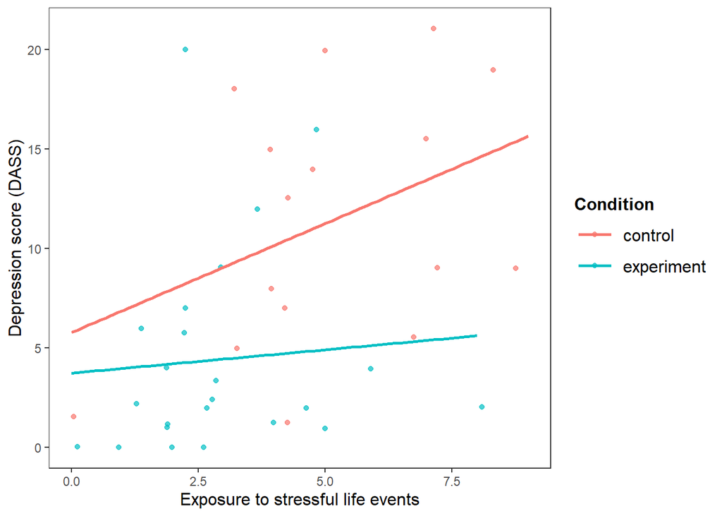

```r
#Generating plot
 plot <- ggplot(df_tidy,
                aes(x = eventsscore, y = depression, col = group)
                ) +
  geom_point(alpha = .7, position = "jitter")+
  geom_smooth(method = "lm", se = FALSE)


#Adding labels and APA theme
  plot +
    labs(x = "Exposure to stressful life events",
         y = "Depression score (DASS)",
         col = "Condition") +
     theme_apa(legend.pos = "right",
               legend.use.title = TRUE)
```

## Finishing session

If you are running this on R Markdown you can now click on `Knit` to prepare your word document with all the prepared analyses.

**[Go Back to the Tutorial Homepage](https://dcs-training.github.io/)**